# Geographic Variation in Medicare Spending and Hospital Use

Avanika Sane and Kanishka Agarwal  
Descriptive evidence from CMS and USDA data

## Introduction and research question

How did Original Medicare spending change across U.S. states during 2014–2024, and do higher-spending places use more hospital care? We also examine rural–urban differences and Medicaid eligibility. These descriptive comparisons identify priorities for investigation rather than establish which places provide better care.

## Data

CMS<sup>1</sup> provides national, state and county spending, enrollment and utilization measures. The cleaned sample contains 11 national observations, 561 state-year observations (50 states plus DC), and 35,102 county-year observations. USDA<sup>2</sup> classifications match 34,481 county-year rows; 621 are unmatched. Spending and utilization describe Original Medicare, while enrollment counts also cover other Medicare beneficiaries.

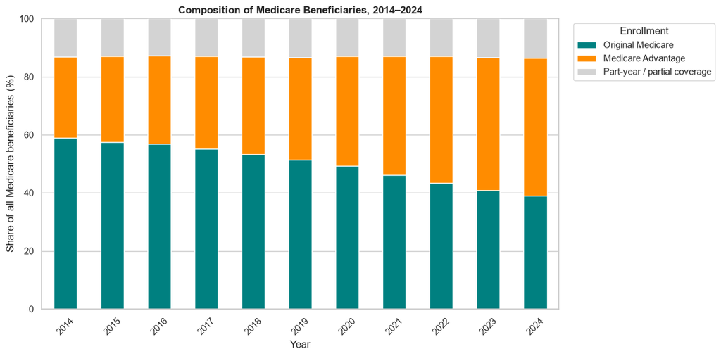

Figure 1. National beneficiary composition, 2014–2024. Shares use total beneficiaries as the denominator.

#### Interpretation

1. **Enrollment shifted steadily toward Medicare Advantage.** Original Medicare's share of all beneficiaries fell from about 59% (2014) to 39% (2024), while Medicare Advantage rose from 28% to 47%, overtaking Original Medicare by 2023. The remaining ~13–14% (part-year or partial-coverage beneficiaries) stayed stable.
2. **Why it matters:** our spending and hospital-use measures cover Original Medicare only, a group that is now a minority of beneficiaries. Results should not be read as describing all of Medicare.

**Note:** shares use total beneficiaries as the denominator, so they differ from CMS's published MA participation rate, which uses Original Medicare + MA.

**Enrollment shares and counts**

| year | Original Medicare | Medicare Advantage | Part-year / partial coverage |
| --- | --- | --- | --- |
| 2014 | 58.95 | 27.90 | 13.15 |
| 2015 | 57.56 | 29.55 | 12.90 |
| 2016 | 56.87 | 30.44 | 12.69 |
| 2017 | 55.12 | 32.00 | 12.88 |
| 2018 | 53.28 | 33.50 | 13.22 |
| 2019 | 51.49 | 35.14 | 13.37 |
| 2020 | 49.22 | 37.86 | 12.92 |
| 2021 | 46.15 | 40.86 | 12.99 |
| 2022 | 43.47 | 43.52 | 13.01 |
| 2023 | 40.87 | 45.82 | 13.32 |
| 2024 | 39.04 | 47.41 | 13.55 |

## Methods

Standardized spending removes geographic payment-rate differences, but does not adjust for health risk or inflation. We retain all-age observations, exclude territories, and leave suppressed values missing. Spending averages use OM-beneficiary weights; readmission comparisons use estimated inpatient-stay weights. Correlations use available pairs.<sup>3</sup> USDA codes 1–3 define urban counties and 4–9 rural counties; 2023 classifications apply throughout.

## Findings

The figures below present spending trends, geographic differences, hospital-use associations and county comparisons.

### Spending trends across states

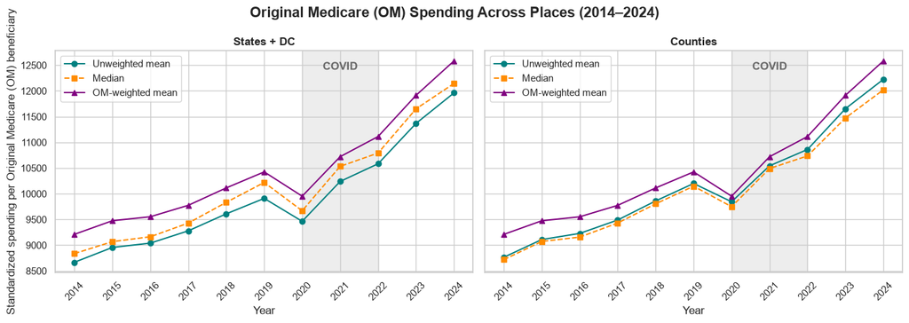

Figure 2. State and county spending summaries, 2014–2024. Gray shading highlights 2020–2022.

#### Interpretation

1. **Original Medicare (OM) standardized spending per beneficiary increased overall between 2014 and 2024** at both the state and county levels. This upward trend was interrupted by a decline in 2020, followed by increases from 2021 onward. The decline coincides with the COVID-19 pandemic, highlighted by the gray shading, although the graph alone cannot establish its cause.
2. **Accounting for beneficiary population changes the spending picture.** The OM-weighted mean remains above the unweighted mean in both panels, indicating that places with larger Original Medicare populations tend to have higher spending per beneficiary. The weighted means also closely align across the state and county panels, consistent with both geographic levels summarizing largely the same underlying population.
3. **The unweighted mean and median reveal additional differences between the geographic levels.** Across states, the mean remains below the median, suggesting that lower-spending states pull the average downward. Across counties, the mean is slightly above the median, suggesting that higher-spending counties pull the average upward.

**Notes:** Unweighted measures give each place equal weight, while the weighted mean uses Original Medicare beneficiary counts. Missing spending is excluded, and weighted calculations also require valid beneficiary counts. Spending is standardized for geographic payment differences but is not adjusted for inflation, so the increase over time should not be interpreted entirely as increased use of care.

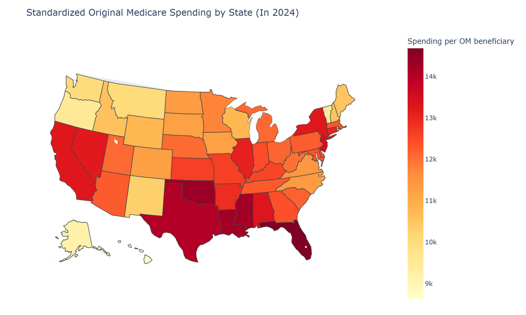

Figure 3. Standardized OM spending per beneficiary by state, 2024.

#### Interpretation

1. Standardized spending per Original Medicare beneficiary varies substantially across states. Florida has the highest spending at $14,680, while Hawaii has the lowest at $8,622—a difference of $6,058 per beneficiary.
2. **Higher spending is concentrated in several southern states**, including Florida, Oklahoma, Mississippi, Louisiana, and Texas. Lower spending appears in Hawaii, Alaska, Oregon, Vermont, and Montana. However, the map also shows variation within broad regions, so geography alone does not explain the differences.
3. Because spending is standardized for geographic payment-rate differences, the darker shades cannot simply be attributed to higher local payment rates. Differences may reflect service use, beneficiary health needs, and other factors that this map does not separate. Higher spending therefore does not, by itself, indicate better care or greater inefficiency.

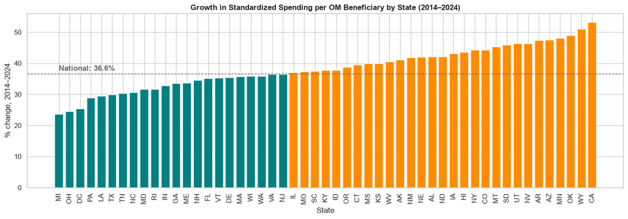

Figure 4. State spending growth, 2014–2024, compared with national growth.

#### Interpretation

1. **The highest and lowest spenders were very stable.** Louisiana had the highest standardized spending per OM beneficiary in every year from 2014 to 2023, with Florida taking the top position in 2024. Hawaii had the lowest spending in all 11 years.
2. **Spending grew in every state, but at very different rates.** Nationally, standardized spending per OM beneficiary rose 36.6% between 2014 and 2024. Growth ranged from 23.7% in Michigan to 53.2% in California.
3. **States that started with lower spending tended to grow faster** (correlation between 2014 spending and growth = −0.46). For example, Wyoming and Minnesota started below average and grew by about 50%, while Louisiana, the highest spender for most of the period, grew by 30%. This is a moderate tendency rather than a rule.
4. **As a result, states became slightly more similar relative to the average, even though the dollar gap widened.** The difference between the highest- and lowest-spending state grew from $4,992 to $6,058, but the coefficient of variation (spread relative to the mean) fell from 0.13 to 0.11. In other words, spending rose everywhere, and the gap grew in dollars but not as a share of typical spending.

**Note:** Percentages are calculated from nominal dollars. Because every state faces the same inflation, comparisons between states are fair, but the national 36.6% should not be read as a 36.6% increase in care.

**States with lowest and highest spending growth**

| year name | 2014 | 2024 | pct_change | vs_national |
| --- | --- | --- | --- | --- |
| MI | 9,767 | 12,079 | 23.70 | -12.90 |
| OH | 9,754 | 12,145 | 24.50 | -12.10 |
| DC | 9,673 | 12,133 | 25.40 | -11.10 |
| PA | 9,485 | 12,223 | 28.90 | -7.70 |
| LA | 10,997 | 14,247 | 29.60 | -7.00 |

| year name | 2014 | 2024 | pct_change | vs_national |
| --- | --- | --- | --- | --- |
| AZ | 8,302 | 12,251 | 47.60 | 11.00 |
| MN | 7,944 | 11,764 | 48.10 | 11.50 |
| OK | 9,606 | 14,318 | 49.10 | 12.50 |
| WY | 7,152 | 10,805 | 51.10 | 14.50 |
| CA | 8,649 | 13,254 | 53.20 | 16.70 |

**Annual state spending dispersion**

| year | mean | std | min | max | gap_max_min | cv |
| --- | --- | --- | --- | --- | --- | --- |
| 2014 | 8,668 | 1,111 | 6,005 | 10,997 | 4,992 | 0.13 |
| 2015 | 8,956 | 1,103 | 6,266 | 11,266 | 5,000 | 0.12 |
| 2016 | 9,040 | 1,089 | 6,441 | 11,400 | 4,959 | 0.12 |
| 2017 | 9,279 | 1,094 | 6,675 | 11,539 | 4,864 | 0.12 |
| 2018 | 9,610 | 1,130 | 6,914 | 11,949 | 5,035 | 0.12 |
| 2019 | 9,910 | 1,192 | 7,128 | 12,204 | 5,076 | 0.12 |
| 2020 | 9,464 | 1,215 | 6,659 | 12,095 | 5,436 | 0.13 |
| 2021 | 10,240 | 1,185 | 7,313 | 12,477 | 5,164 | 0.12 |
| 2022 | 10,583 | 1,246 | 7,651 | 13,055 | 5,404 | 0.12 |
| 2023 | 11,369 | 1,316 | 8,203 | 13,805 | 5,602 | 0.12 |
| 2024 | 11,962 | 1,374 | 8,622 | 14,680 | 6,058 | 0.11 |

**Highest- and lowest-spending states by year**

|  | Year | Highest state | Highest ($) | Lowest state | Lowest ($) |
| --- | --- | --- | --- | --- | --- |
| 0 | 2014 | LA | 10,997 | HI | 6,005 |
| 1 | 2015 | LA | 11,266 | HI | 6,266 |
| 2 | 2016 | LA | 11,400 | HI | 6,441 |
| 3 | 2017 | LA | 11,539 | HI | 6,675 |
| 4 | 2018 | LA | 11,949 | HI | 6,914 |
| 5 | 2019 | LA | 12,204 | HI | 7,128 |
| 6 | 2020 | LA | 12,095 | HI | 6,659 |
| 7 | 2021 | LA | 12,477 | HI | 7,313 |
| 8 | 2022 | LA | 13,055 | HI | 7,651 |
| 9 | 2023 | LA | 13,805 | HI | 8,203 |
| 10 | 2024 | FL | 14,680 | HI | 8,622 |

### Spending and hospital use

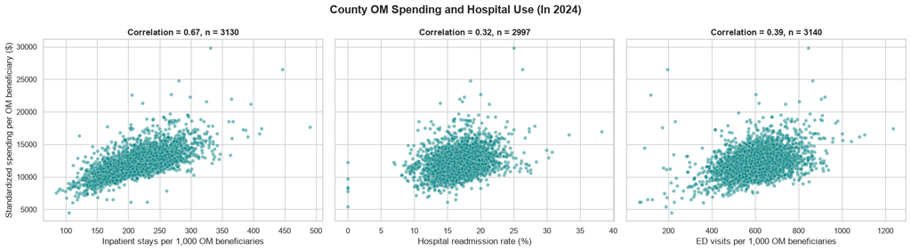

Figure 5. County spending against inpatient stays, readmissions and ED visits, 2024.

#### Interpretation

1. **Counties with more inpatient stays have higher spending** (r = 0.67, 3,130 counties), the clearest relationship of the three. Because total spending includes inpatient payments, part of this is automatic; we test this directly below.
2. **The links with ED visits (r = 0.39) and readmissions (r = 0.32) are weaker**, with much more scatter. If higher spending bought better hospital care, readmissions would be lower in high-spending counties; instead the correlation is positive.
3. **Counts differ by panel** (3,130 / 2,997 / 3,140) because each comparison drops counties missing either value.

**County correlation results**

|  | Hospital-use measure | Correlation | Counties included |
| --- | --- | --- | --- |
| 0 | Inpatient stays per 1,000 OM beneficiaries | 0.67 | 3130 |
| 1 | Hospital readmission rate (%) | 0.32 | 2997 |
| 2 | ED visits per 1,000 OM beneficiaries | 0.39 | 3140 |

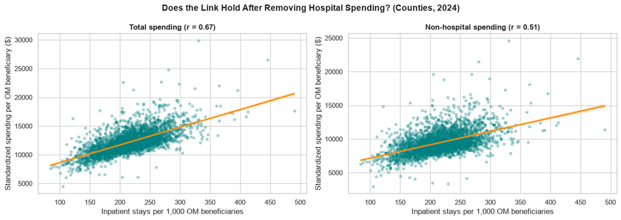

Figure 6. Inpatient stays against total spending and spending excluding inpatient payments, 2024.

#### Interpretation

1. **The link holds after removing hospital spending.** Total spending includes inpatient spending, so part of the original correlation was automatic. With inpatient spending removed, the correlation with inpatient stays falls from 0.67 to 0.51 (counties) and from 0.81 to 0.69 (states), but stays clearly positive. Places that spend more on care outside the hospital also use more hospital care.
2. **It is stronger for states** because averaging over many counties smooths out noise
3. **It is not driven by outliers**: Spearman rank correlations are similar (0.51 counties, 0.65 states).

**Pearson and Spearman correlations: states and counties**

|  | Level | r: total spending | r: non-hospital spending | Spearman: total spending | Spearman: non-hospital spending | n |
| --- | --- | --- | --- | --- | --- | --- |
| 0 | States | 0.81 | 0.69 | 0.78 | 0.65 | 51 |
| 1 | Counties | 0.67 | 0.51 | 0.67 | 0.51 | 3130 |

### Rural vs urban counties

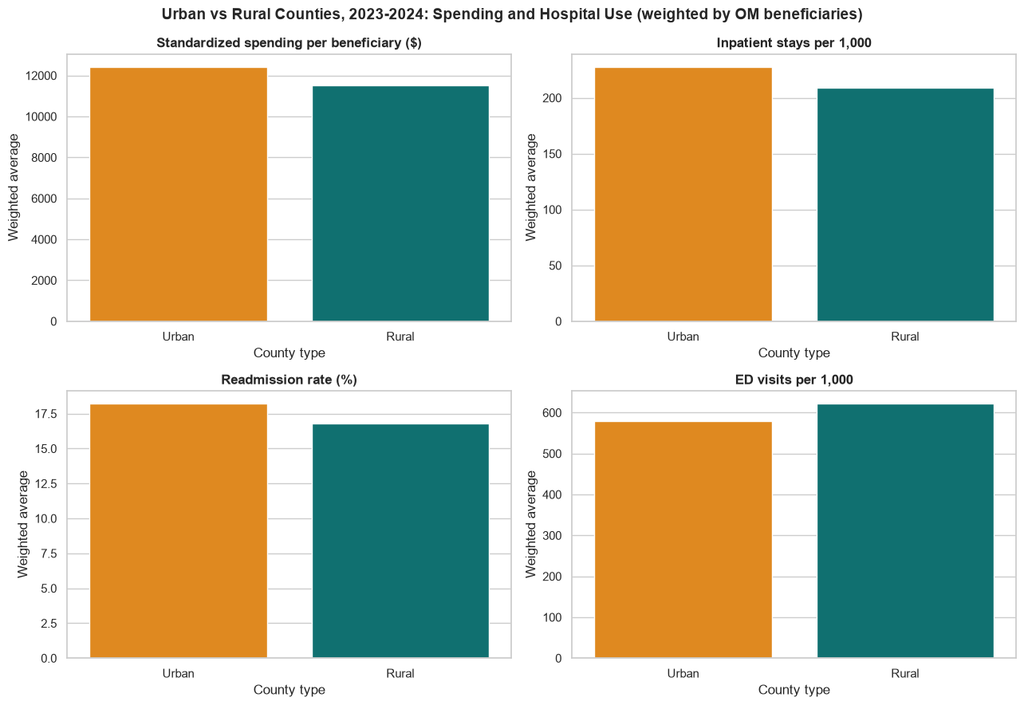

#### Interpretation

1. **Urban counties spend more and use more inpatient care.** In 2023–2024, urban counties averaged $12,433 per beneficiary vs $11,519 in rural counties, with more inpatient stays (228 vs 209 per 1,000) and higher readmission rates (18.2% vs 16.8%).
2. **Rural counties use the emergency department more** (622 vs 579 visits per 1,000), despite fewer admissions. This may reflect less access to regular primary care, though our data cannot confirm the cause.
3. **Weighting changes the spending picture.** Unweighted, rural and urban spending look almost equal ($11,930 vs $11,958), because each small rural county counts as much as a large metro county. Weighted by beneficiaries, a clear urban–rural gap appears.
4. **The pattern was the same before COVID (2014–2019)**, so it is not a post-pandemic effect.

**Notes:** 2020–2022 are excluded as pandemic-disruption years. Rural/urban status uses 2023 USDA codes for all years; counties without a code (mainly Connecticut) are excluded. Dollars are nominal, so compare urban with rural within a period rather than across periods.

**Period comparisons and weighted versus unweighted spending**

| period rural_urban measure | Pre: 2014–2019 Urban | Pre: 2014–2019 Rural | Post: 2023–2024 Urban | Post: 2023–2024 Rural |
| --- | --- | --- | --- | --- |
| Standardized spending per beneficiary ($) | 9,896 | 9,251 | 12,433 | 11,519 |
| Inpatient stays per 1,000 | 275 | 265 | 228 | 209 |
| Readmission rate (%) | 18.30 | 17.00 | 18.20 | 16.80 |
| ED visits per 1,000 | 662 | 725 | 579 | 622 |

|  | rural_urban | period | weighted_mean | unweighted_mean |
| --- | --- | --- | --- | --- |
| 0 | Rural | Post: 2023–2024 | 11,519 | 11,930 |
| 1 | Rural | Pre: 2014–2019 | 9,251 | 9,377 |
| 2 | Urban | Post: 2023–2024 | 12,433 | 11,958 |
| 3 | Urban | Pre: 2014–2019 | 9,897 | 9,549 |

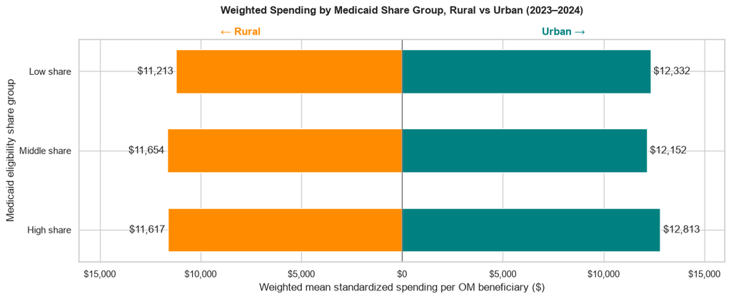

Figure 8. Weighted spending by county Medicaid eligibility tercile and rural/urban status, 2023–2024. Leftward bars represent positive rural spending.

#### Interpretation

**Medicaid group boundaries, spending and distinct county counts**

| medicaid_group | min | max |
| --- | --- | --- |
| Low share | 0.00 | 11.15 |
| Middle share | 11.16 | 16.27 |
| High share | 16.27 | 70.62 |

| rural_urban medicaid_group | Rural | Urban | Gap (Urban − Rural) |
| --- | --- | --- | --- |
| Low share | 11,213 | 12,332 | 1,119 |
| Middle share | 11,654 | 12,152 | 498 |
| High share | 11,617 | 12,813 | 1,197 |

| rural_urban medicaid_group | Rural | Urban |
| --- | --- | --- |
| Low share | 530 | 511 |
| Middle share | 659 | 383 |
| High share | 750 | 290 |

## 5 Recommendations

1. **Look beyond the hospital.** Because non-hospital spending also tracks inpatient use, reviews of high-spending areas should cover care outside the hospital, not only admissions.
2. **Measure need first.** CMS should restore a risk score to the public file, so that spending differences can be compared after accounting for patient health.
3. **Study rural ED use.** Higher ED use despite fewer admissions warrants research into rural primary-care access.

## 6 Limitations

The data cover Original Medicare only, a shrinking share of beneficiaries (Figure 1). We could not adjust for health risk: the average HCC risk score in earlier releases in the 2014–2023 release is absent from the 2014–2024 file, and Medicaid share is only a rough proxy. Correlation is not causation, and place-level results do not describe individual patients (the ecological fallacy). Dollars are nominal, 2023 rural-urban codes are applied to all years, and suppressed values are concentrated in small, mostly rural counties.

## 7 Reproducibility

Code and data are available at https://github.com/avanikasane/medicare-geographic-variation. Running `notebooks/01_cleaning.ipynb` and then `notebooks/02_analysis.ipynb` recreates the cleaned files in `data/clean/` and every figure in `report/figures/`.

## Appendix: moving-average forecast

**The 2-year moving average performed better historically.** Using identical historical comparison years (2017–2024), the 2-year moving average had lower MAD ($608.81 versus $697.17) and MAPE (5.46% versus 6.21%). Both lagged rising spending and overestimated the 2020 decline. These are retrospective one-year-ahead comparisons, not accuracy measurements for 2025.

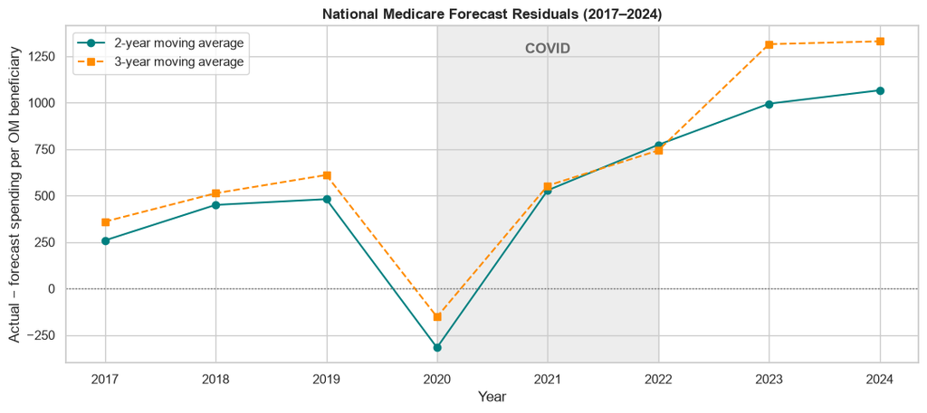

Figure 9. National forecast residuals (actual minus forecast), 2017–2024. Positive values indicate underprediction.

#### Interpretation

1. The **2-year moving average performed better overall** during 2017–2024. Its MAD was 608.81 per beneficiary, compared with $697.17 for the 3-year method. Its MAPE was also lower.
2. Both methods generally underestimated spending as it increased over time. In 2024, actual standardized spending was $12,553 per OM beneficiary while the 2-year forecast was 11,486.50 and the 3-year forecast was $11,223. Moving averages lag behind a rising trend because they rely on earlier, lower spending values.
3. The pattern reversed in 2020, when spending declined and both methods overestimated it. This illustrates their limited ability to anticipate sudden changes. Although the 2-year method was more accurate overall, it was not better in every individual year.
4. Forecast for 2025: the 2-year moving average, the more accurate method historically, predicts about $12,220 per beneficiary. Because moving averages lag behind a rising trend, actual 2025 spending is likely to be higher.

**Forecast limitation:** Actual CMS observations are available through 2024. The 2025 estimates cannot yet be evaluated. A rising historical trend does not guarantee that actual 2025 spending will exceed the forecast.

**Historical predictions and forecast accuracy**

|  | year | spend_pc_std | forecast_2yr | forecast_3yr |
| --- | --- | --- | --- | --- |
| 3 | 2017 | 9,753 | 9,494 | 9,393 |
| 4 | 2018 | 10,093 | 9,643 | 9,580 |
| 5 | 2019 | 10,404 | 9,923 | 9,793 |
| 6 | 2020 | 9,931 | 10,248 | 10,083 |
| 7 | 2021 | 10,696 | 10,168 | 10,143 |
| 8 | 2022 | 11,087 | 10,314 | 10,344 |
| 9 | 2023 | 11,886 | 10,892 | 10,571 |
| 10 | 2024 | 12,553 | 11,486 | 11,223 |

|  | Method | MAD | MAPE (%) |
| --- | --- | --- | --- |
| 0 | forecast_2yr | 609 | 5.46 |
| 1 | forecast_3yr | 697 | 6.21 |

## Use of AI tools

We used ChatGPT and Claude for support with Python code, debugging, and making the report HTML file. All analysis decisions, interpretation and final writing are our own, and every result was checked against the data.

## Footnotes

[^1]: Centers for Medicare & Medicaid Services (CMS). *Medicare Geographic Variation – by National, State & County* (2014–2024 public use file). data.cms.gov; listed on data.gov as issued December 9, 2025 and last modified May 15, 2026. https://data.cms.gov/summary-statistics-on-use-and-payments/medicare-geographic-comparisons/medicare-geographic-variation-by-national-state-county. Its data dictionary, *2014–2024 Original Medicare Geographic Variation by National, State & County Data Dictionary* (CMS, n.d.), defines the spending and utilization measures for Original Medicare beneficiaries, which it describes as “the traditional Medicare Fee-for-Service (FFS) program covering Part A and Part B”, and notes that all variables are suppressed (marked “*”) where the count of beneficiaries or users is less than 11. https://data.cms.gov/sites/default/files/2026-05/267755af-8e26-4bcd-a3ea-fef41c96b7fc/2014-2024%20Original%20Medicare%20Geographic%20Variation%20Data%20Dictionary.pdf
[^2]: U.S. Department of Agriculture, Economic Research Service (USDA ERS). *Rural-Urban Continuum Codes, 2023*. Released January 2024. Codes 1–3 classify metropolitan counties by metro-area population; codes 4–9 classify nonmetropolitan counties by urban population and adjacency to a metro area. https://www.ers.usda.gov/data-products/rural-urban-continuum-codes
[^3]: The pandas development team. “pandas.DataFrame.corr.” *pandas documentation* (pandas 3.0). Source for the Pearson (“standard correlation coefficient”) and Spearman (“Spearman rank correlation”) methods. https://pandas.pydata.org/docs/reference/api/pandas.DataFrame.corr.html